# Sampling & Inference Practice Problems

Elise Haylett

4/13/2020

```r
library(infer)
library(tidyverse)
library(combinat)
library(kableExtra)

FlightDelays <- read_csv(file = url("https://raw.githubusercontent.com/STAT-JET-ASU/Datasets/master/Chihara/FlightDelays.csv"))
```

#### Exercise 3.5

In the flight delays case study, the data contain flight delays for two airlines, American Airlines and United Airlines.  
a) Conduct a two-sided permutation test to see if the difference in mean delay times between the two carriers are statistically significant.

```r
carrier_delay <- FlightDelays %>%
  group_by(Carrier) %>%
  summarize(n = n(),
            xbar = mean(Delay),
            s = sd(Delay))

carrier_delay
```

```
# A tibble: 2 x 4
  Carrier     n  xbar     s
  <chr>   <int> <dbl> <dbl>
1 AA       2906  10.1  40.1
2 UA       1123  16.0  45.1
```

```r
obs_diff <- diff(carrier_delay$xbar) # xbar_UA - xbar_AA

sprintf("The observed mean difference (xbar_UA - xbar_AA) is %1.2f minutes.", obs_diff) # test statistic
```

```
[1] "The observed mean difference (xbar_UA - xbar_AA) is 5.89 minutes."
```

```r
set.seed(1)

simdata <- pull(FlightDelays, Delay)
total_n <- length(simdata)
group_n <- carrier_delay$n[2]

N_sims <- 10^4 - 1

rand_diffs <- numeric(N_sims)

for (i in 1:N_sims) {
  index <- sample(total_n, group_n)
  rand_diffs[i] <- mean(simdata[index]) - mean(simdata[-index])
}
```

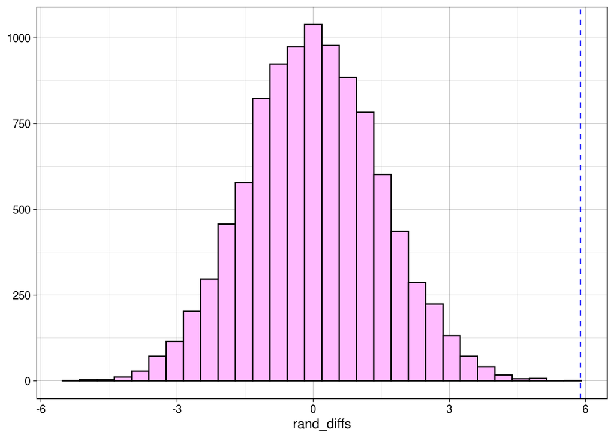

```r
ggplot(NULL, aes(x = rand_diffs)) +
  geom_histogram(bins = 30, color = "black", fill = "plum1") +
  geom_vline(xintercept = obs_diff, color = "blue", linetype = "dashed") +
  theme_linedraw() +
  theme(axis.title.y = element_blank())
```

```r
alpha <- .05
pvalue.two.sided <- 2 * (sum(rand_diffs >= obs_diff) + 1)/(N_sims + 1)
sprintf("The p-value for Ho: mu_UA = mu_AA vs. Ha: mu_UA ≠ mu_AA is %1.5f.", pvalue.two.sided)
```

```
[1] "The p-value for Ho: mu_UA = mu_AA vs. Ha: mu_UA ≠ mu_AA is 0.00020."
```

```r
ifelse(pvalue.two.sided <= alpha, sprintf("Reject Ho."), sprintf("Do not reject Ho."))
```

```
[1] "Reject Ho."
```

b) The flights took place in May and June of 2009. Conduct a two-sided permutation test to see if the difference in mean times between the two months is statistically significant.

```r
month_delay <- FlightDelays %>%
  group_by(Month) %>%
  summarize(n = n(),
            xbar = mean(Delay),
            s = sd(Delay))
month_delay
```

```
# A tibble: 2 x 4
  Month     n  xbar     s
  <chr> <int> <dbl> <dbl>
1 June   2030 14.5   45.5
2 May    1999  8.88  37.1
```

```r
obs_diff <- diff(month_delay$xbar) # xbar_May - xbar_JUne

sprintf("The observed mean difference (xbar_May - xbar_June) is %1.2f minutes.", obs_diff) # test statistic
```

```
[1] "The observed mean difference (xbar_May - xbar_June) is -5.66 minutes."
```

```r
set.seed(1)

simdata <- pull(FlightDelays, Delay)
total_n <- length(simdata)
group_n <- month_delay$n[2]

N_sims <- 10^4 - 1

rand_diffs <- numeric(N_sims)

for (i in 1:N_sims) {
  index <- sample(total_n, group_n)
  rand_diffs[i] <- mean(simdata[index]) - mean(simdata[-index])
}
```

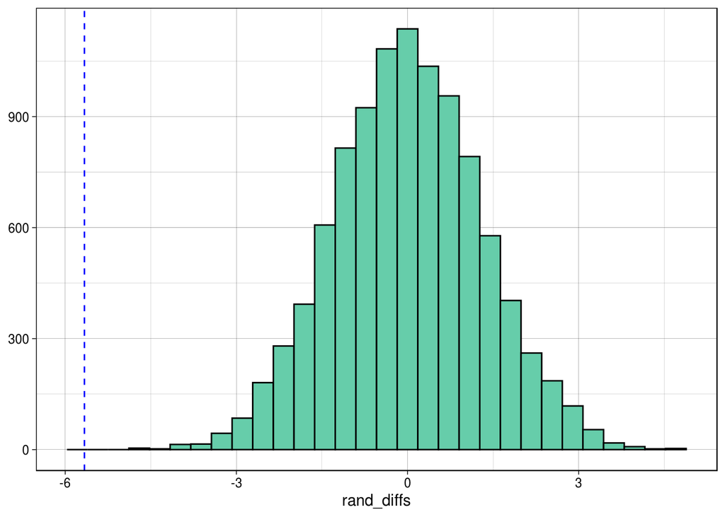

```r
ggplot(NULL, aes(x = rand_diffs)) +
  geom_histogram(bins = 30, color = "black", fill = "mediumaquamarine") +
  geom_vline(xintercept = obs_diff, color = "blue", linetype = "dashed") +
  theme_linedraw() +
  theme(axis.title.y = element_blank())
```

```r
alpha <- .05
pvalue.two.sided <- 2 * (sum(rand_diffs <= obs_diff) + 1)/(N_sims + 1)
sprintf("The p-value for Ho: mu_May = mu_June vs. Ha: mu_May ≠ mu_June is %1.5f.", pvalue.two.sided)
```

```
[1] "The p-value for Ho: mu_May = mu_June vs. Ha: mu_May ≠ mu_June is 0.00020."
```

```r
ifelse(pvalue.two.sided <= alpha, sprintf("Reject Ho."), sprintf("Do not reject Ho."))
```

```
[1] "Reject Ho."
```

#### Exercise 3.9

In the flight delays case study,  
a) Compute the proportion of times the flights in May and in June were delayed more than 20 minutes, and conduct a two-sided test to see if the difference between months is statistically significant.

```r
prop_delay <- FlightDelays %>%
  group_by(Month) %>%
  summarize(n = n(),
            prop = mean(Delay > 20)) %>%
  arrange(desc(Month))
prop_delay
```

```
# A tibble: 2 x 3
  Month     n  prop
  <chr> <int> <dbl>
1 May    1999 0.167
2 June   2030 0.196
```

```r
prop_diff <- diff(prop_delay$prop) # prop_June - prop_May

sprintf("The difference in proportion of times flights in May and June were delayed more than 20 minutes is %1.3f.", prop_diff)
```

```
[1] "The difference in proportion of times flights in May and June were delayed more than 20 minutes is 0.029."
```

```r
set.seed(1)

simdata <- pull(FlightDelays, Delay)
total_n <- length(simdata)
group_n <- prop_delay$n[2]

N_sims <- 10^4 - 1

rand_diffs <- numeric(N_sims)

for (i in 1:N_sims) {
  index <- sample(total_n, group_n)
  rand_diffs[i] <- mean(simdata[index] > 20) - mean(simdata[-index] > 20)
}
```

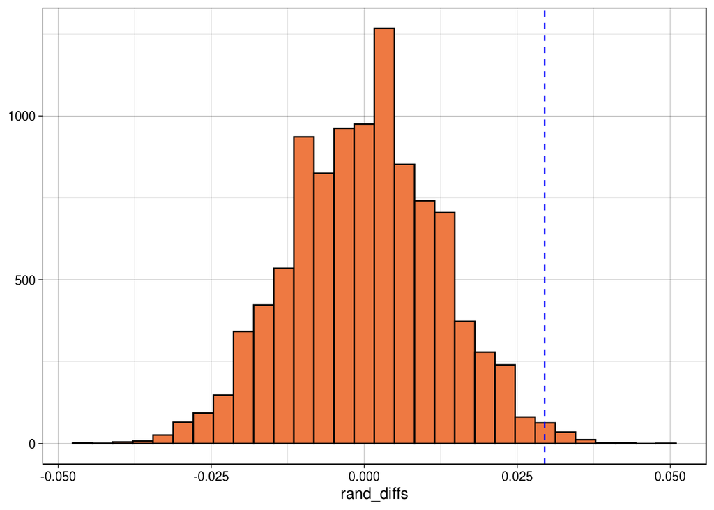

```r
ggplot(NULL, aes(x = rand_diffs)) +
  geom_histogram(bins = 30, color = "black", fill = "sienna2") +
  geom_vline(xintercept = prop_diff, color = "blue", linetype = "dashed") +
  theme_linedraw() +
  theme(axis.title.y = element_blank())
```

```r
alpha <- .05
pvalue.two.sided <- 2 * (sum(rand_diffs >= prop_diff) + 1)/(N_sims + 1)
sprintf("The p-value for Ho: phat_May = phat_June vs. Ha: phat_May ≠ phat_June is %1.5f.", pvalue.two.sided)
```

```
[1] "The p-value for Ho: phat_May = phat_June vs. Ha: phat_May ≠ phat_June is 0.01680."
```

```r
ifelse(pvalue.two.sided <= alpha, sprintf("Reject Ho."), sprintf("Do not reject Ho."))
```

```
[1] "Reject Ho."
```

b) Compute the ratio of the variances in the flight delay times in May and in June. Is this evidence that the true ratio is not equal to 1 or could this be due to chance variability? Conduct a two-sided test to check.

```r
var_delay <- FlightDelays %>%
  group_by(Month) %>%
  summarize(n = n(),
            variance = var(Delay)) %>%
  arrange(desc(Month))
var_delay
```

```
# A tibble: 2 x 3
  Month     n variance
  <chr> <int>    <dbl>
1 May    1999    1376.
2 June   2030    2070.
```

```r
var_obs <- var_delay$variance[1] / var_delay$variance[2]

sprintf("The ratio of variances in the flight delay times in May and June is %1.3f.", var_obs)
```

```
[1] "The ratio of variances in the flight delay times in May and June is 0.665."
```

```r
set.seed(1)

simdata <- pull(FlightDelays, Delay)
total_n <- length(simdata)
group_n <- var_delay$n[1]

N_sims <- 10^5 - 1

result <- numeric(N_sims)

for (i in 1:N_sims) {
  index <- sample(total_n, group_n)
  rand_diffs[i] <- var(simdata[index]) - var(simdata[-index])
}
```

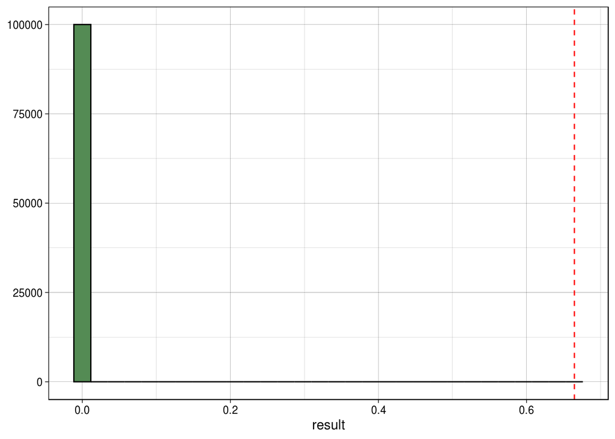

```r
ggplot(NULL, aes(x = result)) +
  geom_histogram(bins = 30, color = "black", fill = "palegreen4") +
  geom_vline(xintercept = var_obs, color = "red", linetype = "dashed") +
  theme_linedraw() +
  theme(axis.title.y = element_blank())
```

```r
alpha <- .05
pvalue.two.sided <- 2 * (sum(result >= var_obs) + 1)/(N_sims + 1)
sprintf("The p-value for Ho: true ratio = 1 vs. Ha: true ratio ≠ 1 is %1.5f.", pvalue.two.sided)
```

```
[1] "The p-value for Ho: true ratio = 1 vs. Ha: true ratio ≠ 1 is 0.00002."
```

```r
ifelse(pvalue.two.sided <= alpha, sprintf("Reject Ho."), sprintf("Do not reject Ho."))
```

```
[1] "Reject Ho."
```

#### Exercise 4.7

The data set `FlightDelays` contains the population of all flight departures by United Airlines and American Airlines out of LGA during May and June of 2009.  
a) Create a histogram of `Delay` and describe the distribution. Compute the mean and standard deviation.

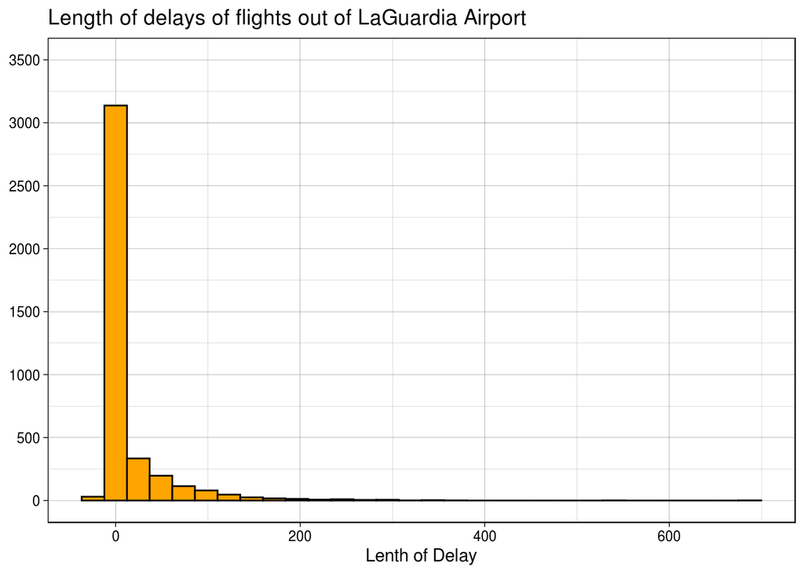

```r
ggplot(FlightDelays, aes(x = Delay)) +
  geom_histogram(bins = 30, col = "black", fill = "orange") +
  labs(title = "Length of delays of flights out of LaGuardia Airport",
       x = "Lenth of Delay") +
  scale_y_continuous(limits = c(0, 3500), breaks = seq(0, 3500, by = 500)) +
  theme_linedraw() +
  theme(axis.title.y = element_blank())
```

**The distribution of delay times of flights is right skewed with extremely large outliers.**

```r
FlightDelays %>%
  summarize(mean = mean(Delay),
            sd = sd(Delay))
```

```
# A tibble: 1 x 2
   mean    sd
  <dbl> <dbl>
1  11.7  41.6
```

b) Simulate the sampling distribution of $\bar{x}$, the sample mean of the length of the flight delays (`Delay`), for samples of size 25. Create a histogram and describe the simulated sampling distribution of $\bar{x}$. Estimate the mean and standard error.

```r
mu <- 11.7379

delays <- FlightDelays$Delay

sims  <- 1000              # number of samples
delays_N <- length(delays)  # population size
n     <- 25                 # sample size

xbar <- numeric(sims) # vector to store the means of the random samples

for (i in 1:sims) {
  delay_samp    <- sample(delays_N, n)           # randomly choose n sample IDs
  xbar[i] <- mean(delays[delay_samp])  # compute/store the sample mean
}
```

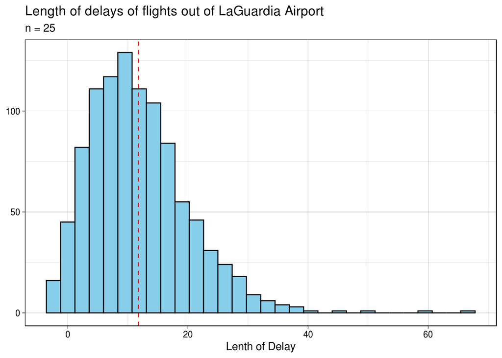

```r
ggplot(NULL, aes(x = xbar)) +
  geom_histogram(bins = 30, color = "black", fill = "skyblue") +
  geom_vline(xintercept = mu, color = "red", linetype = "dashed") +
  theme_linedraw() +
  labs(title = "Length of delays of flights out of LaGuardia Airport",
       subtitle = "n = 25",
       x = "Lenth of Delay") +
  theme(axis.title.y = element_blank())
```

```r
mean(xbar)
```

```
[1] 11.8584
```

```r
sd(xbar)
```

```
[1] 8.250197
```

d) Repeat the above using samples of size 250 and compare with the $n = 25$ scenario.

```r
mu <- 11.7379

delays <- FlightDelays$Delay

sims  <- 1000              # number of samples
delays_N <- length(delays)  # population size
n     <- 250                 # sample size

xbar <- numeric(sims) # vector to store the means of the random samples

for (i in 1:sims) {
  delay_samp    <- sample(delays_N, n)           # randomly choose n sample IDs
  xbar[i] <- mean(delays[delay_samp])  # compute/store the sample mean
}
```

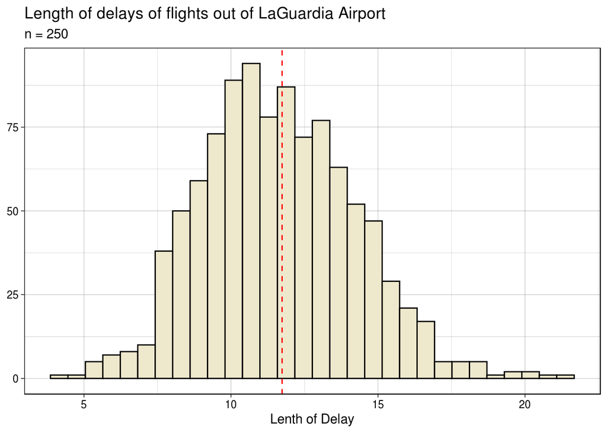

```r
ggplot(NULL, aes(x = xbar)) +
  geom_histogram(bins = 30, color = "black", fill = "cornsilk2") +
  geom_vline(xintercept = mu, color = "red", linetype = "dashed") +
  theme_linedraw() +
  labs(title = "Length of delays of flights out of LaGuardia Airport",
       subtitle = "n = 250",
       x = "Lenth of Delay") +
  theme(axis.title.y = element_blank())
```

```r
mean(xbar)
```

```
[1] 11.62918
```

```r
sd(xbar)
```

```
[1] 2.592603
```

#### Exercise 4.20

Let $X_1, X_2, ..., X_9$ ~ $N(7, 3^2)$, and $Y_1, Y_2, ..., Y_{12}$ ~ $N(10, 5^2)$. Let $W = \bar{X} - \bar{Y}$.  
a) Give the exact sampling distribution of $W$.

```r
xbar <- 7
ybar <- 10
(mu_W <- xbar - ybar)
```

```
[1] -3
```

```r
n <- 30

s_x <- 3 / sqrt(n)
s_y <- 5 / sqrt(n)
(s_W <- s_x + s_y)
```

```
[1] 1.460593
```

```r
(var_W <- (s_W)^2)
```

```
[1] 2.133333
```

b) Simulate the sampling distribution $W$ in `R`, and plot your results (adapt code from the previous exercise). Check that the simulated mean and standard error are close to the theoretical mean and standard error.

```r
W <- numeric(1000)
for (i in 1:1000) {
  x <- rnorm(10, 7, 3)
  y <- rnorm(15, 10, 5)
  W[i] <- mean(x) - mean(y)
}
```

```r
mean(W)
```

```
[1] -3.004944
```

```r
sd(W)
```

```
[1] 1.602014
```

c) Use your simulation to find $P(W < -1.5)$. Calculate an exact answer and compare.

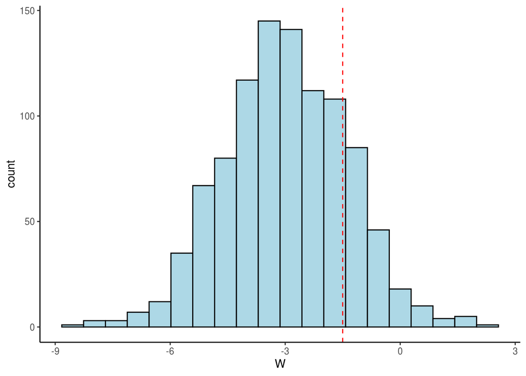

```r
ggplot(NULL, aes(x = W)) +
  geom_histogram(bins = 20, color = "black", fill = "lightblue") +
  geom_vline(xintercept = -1.5, color = "red", linetype = "dashed") +
  theme_classic()
```

```r
mean(W < -1.5)
```

```
[1] 0.821
```

#### Semmelweiss

```r
data <- "https://raw.githubusercontent.com/STAT-JET-ASU/Datasets/master/Instructor/semmelweisannualbyclinic.csv"
by_clinic <- read_csv(file = url(data)) %>%
  mutate(mortality = 100 * deaths / births)

glimpse(by_clinic)
```

```
Rows: 12
Columns: 5
$ year      <dbl> 1841, 1842, 1843, 1844, 1845, 1846, 1841, 1842, 1843, 1844,…
$ births    <dbl> 3036, 3287, 3060, 3157, 3492, 4010, 2442, 2659, 2739, 2956,…
$ deaths    <dbl> 237, 518, 274, 260, 241, 459, 86, 202, 164, 68, 66, 105
$ clinic    <chr> "clinic 1", "clinic 1", "clinic 1", "clinic 1", "clinic 1",…
$ mortality <dbl> 7.806324, 15.759051, 8.954248, 8.235667, 6.901489, 11.44638…
```

```r
head(by_clinic)
```

```
# A tibble: 6 x 5
   year births deaths clinic   mortality
  <dbl>  <dbl>  <dbl> <chr>        <dbl>
1  1841   3036    237 clinic 1      7.81
2  1842   3287    518 clinic 1     15.8
3  1843   3060    274 clinic 1      8.95
4  1844   3157    260 clinic 1      8.24
5  1845   3492    241 clinic 1      6.90
6  1846   4010    459 clinic 1     11.4
```

```r
handwashing_start <- as.Date("1847-06-01")
data <- "https://raw.githubusercontent.com/STAT-JET-ASU/Datasets/master/Instructor/semmelweismonthly.csv"
by_month <- read_csv(file = url(data)) %>%
  mutate(mortality = 100 * deaths / births,
         handwashing = ifelse(date < handwashing_start, "dirty", "washed"))

glimpse(by_month)
```

```
Rows: 98
Columns: 5
$ date        <date> 1841-01-01, 1841-02-01, 1841-03-01, 1841-04-01, 1841-05-…
$ births      <dbl> 254, 239, 277, 255, 255, 200, 190, 222, 213, 236, 235, 30…
$ deaths      <dbl> 37, 18, 12, 4, 2, 10, 16, 3, 4, 26, 53, 64, 38, 27, 26, 1…
$ mortality   <dbl> 14.5669291, 7.5313808, 4.3321300, 1.5686275, 0.7843137, 5…
$ handwashing <chr> "dirty", "dirty", "dirty", "dirty", "dirty", "dirty", "di…
```

```r
head(by_month)
```

```
# A tibble: 6 x 5
  date       births deaths mortality handwashing
  <date>      <dbl>  <dbl>     <dbl> <chr>
1 1841-01-01    254     37    14.6   dirty
2 1841-02-01    239     18     7.53  dirty
3 1841-03-01    277     12     4.33  dirty
4 1841-04-01    255      4     1.57  dirty
5 1841-05-01    255      2     0.784 dirty
6 1841-06-01    200     10     5     dirty
```

Consider the Semmelweiss activity from Week 1. Conduct a permutation resampling test to determine whether the average mortality for Clinic 1 was statistically significantly greater than the average mortality for Clinic 2 between 1841 and 1846 (one-tailed test).
$$H_0: \mu_1 = \mu_2$$
$$H_A: \mu_1 > \mu_2$$

```r
mortality <- by_clinic %>%
  group_by(clinic) %>%
  summarize(n = n(),
            average = mean(mortality))

(clinic_diff <- diff(mortality$average)) # clinic 2 - clinic 1
```

```
[1] -5.810534
```

```r
set.seed(1)

sim_data <- pull(by_clinic, mortality)
total_n <- length(sim_data)
group_n <- mortality$n[2]

N <- 10^4 - 1
difference <- numeric(N)

for (i in 1:N) {
  index <- sample(total_n, group_n)
  difference[i] <- mean(sim_data[index]) - mean(sim_data[-index])
}
```

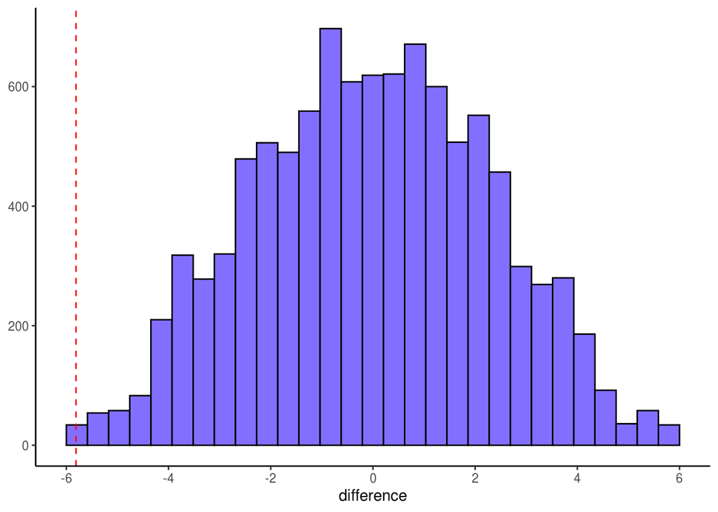

```r
ggplot(NULL, aes(x = difference)) +
  geom_histogram(bins = 30, color = "black", fill = "slateblue1") +
  geom_vline(xintercept = clinic_diff, color = "red", linetype = "dashed") +
  scale_x_continuous(limits = c(-6, 6), breaks = seq(-6, 6, by = 2)) +
  theme_classic() +
  theme(axis.title.y = element_blank())
```

```r
alpha <- .05
pvalue.greater <- (sum(difference >= clinic_diff) + 1)/(N_sims + 1)
sprintf("The p-value for Ho: mu_clinic1 = mu_clinic2 vs. Ha: mu_clinic1 > mu_clinic2 is %1.5f.", pvalue.greater)
```

```
[1] "The p-value for Ho: mu_clinic1 = mu_clinic2 vs. Ha: mu_clinic1 > mu_clinic2 is 0.09987."
```

```r
ifelse(pvalue.greater <= alpha, sprintf("Reject Ho."), sprintf("Do not reject Ho."))
```

```
[1] "Do not reject Ho."
```

```r
handwashing <- by_month %>%
  group_by(handwashing) %>%
  summarize(n = n(),
            average = mean(mortality))

(handwashing_diff <- diff(handwashing$average)) # washed - dirty
```

```
[1] -8.395661
```

```r
set.seed(1)

sim_data <- pull(by_month, mortality)
total_n <- length(sim_data)
group_n <- handwashing$n[2]

N <- 10^4 - 1
difference <- numeric(N)

for (i in 1:N) {
  index <- sample(total_n, group_n, replace = FALSE)
  difference[i] <- mean(sim_data[index]) - mean(sim_data[-index])
}
```

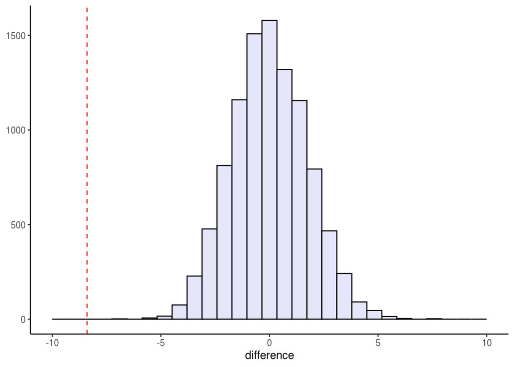

```r
ggplot(NULL, aes(x = difference)) +
  geom_histogram(bins = 30, color = "black", fill = "lavender") +
  geom_vline(xintercept = handwashing_diff, color = "red", linetype = "dashed") +
  scale_x_continuous(limits = c(-10, 10), breaks = seq(-10, 10, by = 5)) +
  theme_classic() +
  theme(axis.title.y = element_blank())
```

```r
alpha <- .05
pvalue.less <- (sum(difference <= handwashing_diff) + 1)/(N_sims + 1)
sprintf("The p-value for Ho: mu_handwashing = mu_dirty vs. Ha: mu_handwashing < mu_dirty is %1.5f.", pvalue.less)
```

```
[1] "The p-value for Ho: mu_handwashing = mu_dirty vs. Ha: mu_handwashing < mu_dirty is 0.00001."
```

```r
ifelse(pvalue.less <= alpha, sprintf("Reject Ho."), sprintf("Do not reject Ho."))
```

```
[1] "Reject Ho."
```